# Prosper Loan Data Exploration

## By Emma Hungrige

## Investigation Overview

Key plots were chosen with high data-to-ink ratio for this presentation. The plots presented shows the distribution of the main variables - IncomeRange, EmploymentStatus, ProsperRating, and EstimatedReturns. These factors help to show some of the major predictors for LoanStatus and ProsperRating variables.

## Dataset Overview

This dataset contains information on peer to peer loans faciliated by the credit company Prosper. There are 113,937 loans with 81 variables. For the purpose of this investigation, the following variables are used:

1. **IncomeRange**
2. **DebtToIncomeRatio**
3. **CreditGrade**
4. **ProsperRating (Alpha)**
5. **EstimatedReturn**
6. **ActualReturn**

## Income Range

Let's look at a couple of the underwriting features for borrowers to be assigned the Prosper Credit Ratings. We'll start with taking a look at Income Ranges.

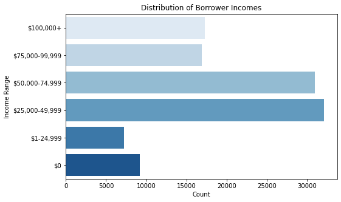

The number of borrowers for the 25k-49k range is the same as the 50k-74k range. The amount of borrowers in the 75k-100k range is the same as all borrowers that have an income of over 100k.

## Employment Status

Let's look at the Employment Status of borrowers now that we've looked into their income ranges.

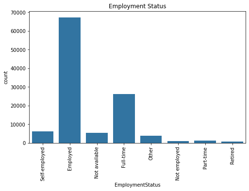

Not surprisingly, the largest category of borrowers are employed and the largest sub-category of the employed status is full-time.

## Income Range and Credit Rating vs Estimated Returns

Let's take a look at how a borrower's income range and credit rating relates to the investor's estimated returns.

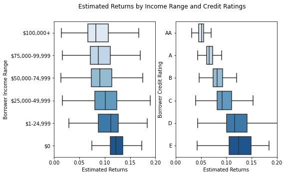

From these boxplot, we're able to clearly see that as the borrowers income increases, the median estimated return decreases.

## Actual Returns

Next let's plot the actual returns.

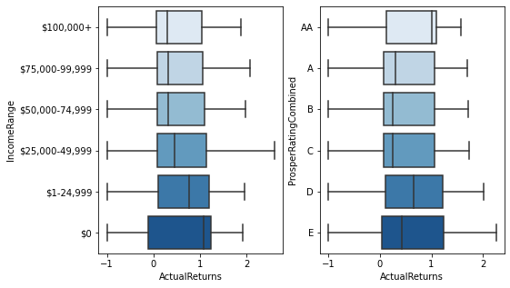

This plot is quite interesting as it suggests that investing in borrowers with no reported income and the highest credit ratings will produce the highest returns.